# Forum Activity By Region

**TO DO: check consistency of calculations, smarten chart labels and legends, add comment calculations? (maybe check significance of difference to posting - if none, consider merging posts and comments as “contibutions”..**

Investigate how people from different regions participate in the forums. Only people in the “student” role (access_group_id=4) are considered. Withdrawn/deleted users are neglected (role and region are unknown).

Regions are derived from the continent and country determined from IP address and comprise a crude proxy for culture and native language. Statistics on English-speaking are not used, but see: http://en.wikipedia.org/wiki/List_of_countries_by_English-speaking_population. The default region is a continent, but the following exceptions are made to this rule:

- UK AND IRELAND designates tha UK, Ireland and the Isle of Man
- EUROPE is the rest of Europe, including countries outside the EU
- CHINA includes Hong Kong and Taiwan
- INDIA is separated from other Asian countries
- AUSTRALIA AND NZ are separated off from Oceania
- Mexico is recoded to CENTRAL AMERICA
- The Caribbean is recoded to CENTRAL AMERICA (small numbers)

The “introductions” forums are considered separately since they have quite a different character to other forums.

## Regional Distribution of Users

Although we are mostly concerned with differences in behaviour, it is also interesting to get a feel for whether or not this is likely to influence the overall forum character. Hence the proportion of users from the regions is of interest.

```
## SELECT c.ip_continent continent, c.ip_country country, count(1) users
##                   FROM vpodata_aiplangen.users u JOIN vpodata_aiplangen.uoe_ip_country c
##                                           ON u.anon_user_id = c.anon_user_id
##                   WHERE u.access_group_id = 4 GROUP BY continent, country
```

| id | EUROPE | NORTH AMERICA | SOUTH AMERICA | AFRICA | ASIA | MIDDLE EAST | CENTRAL AMERICA | UK AND IRELAND | CHINA | AUSTRALIA AND NZ | INDIA |
| --- | --- | --- | --- | --- | --- | --- | --- | --- | --- | --- | --- |
| aiplan | 4345 | 3449 | 1010 | 475 | 1300 | 811 | 314 | 688 | 432 | 240 | 2265 |
| astro | 5079 | 7540 | 1475 | 210 | 1048 | 343 | 397 | 2084 | 324 | 571 | 1084 |
| crit | 9537 | 8574 | 2269 | 1266 | 3920 | 1269 | 893 | 1988 | 1147 | 887 | 2643 |
| edc | 5821 | 6239 | 2064 | 488 | 1441 | 586 | 629 | 2018 | 384 | 968 | 954 |
| equine | 2246 | 5941 | 668 | 190 | 207 | 145 | 186 | 8056 | 64 | 1123 | 84 |
| intro | 12598 | 16648 | 3930 | 857 | 3815 | 1425 | 1127 | 5056 | 1128 | 1944 | 3276 |

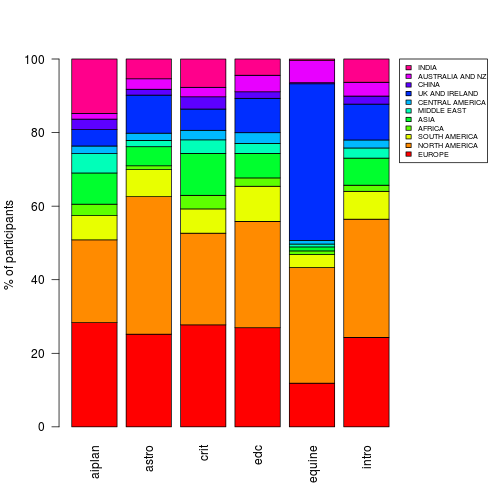

```r
cols <- rainbow(length(userRegions.df[1, ]))
par(mar = c(5.1, 4.1, 4.1, 7.1), xpd = TRUE)
barplot(100 * t(as.matrix(userRegions.df)/rowSums(userRegions.df)), ylab = "% of participants",
    col = cols, las = 2)
legend("topright", inset = c(-0.25, 0), legend = rev(colnames(userRegions.df)),
    fill = rev(cols), cex = 0.6)
```

## Probability of Contributing By Region

Since the number of users differs widely between regions, we will look at the probability that a given user will contribute either a comment or a post.

```r
# specify which forum ids are for personal introductions
intro.fid <- c(aiplan = 10, astro = 12, crit = 2, edc = 25, equine = 2, intro = 11)
# and for technical queries
tech.fid <- c(aiplan = 9, astro = 9, crit = 9, edc = 20, equine = 9, intro = 9)
# all other forums are assumed to be subject matter
```

## Probability of Posting

What is the probability that a randomly chosen person from a given region in each course will have contributed at least 1 post.

```
## SELECT DISTINCT continent, country, count(1) users FROM
## (SELECT DISTINCT c.ip_continent continent, c.ip_country country,  fp.forum_user_id
##  FROM vpodata_aiplanfor.forum_posts fp
##  JOIN vpodata_aiplanmap.hash_mapping m ON m.forum_user_id = fp.forum_user_id
##  JOIN vpodata_aiplangen.uoe_ip_country c ON m.anon_user_id = c.anon_user_id
##  JOIN vpodata_aiplangen.users u ON m.anon_user_id = u.anon_user_id
##  JOIN  vpodata_aiplanfor.forum_threads ft ON fp.thread_id = ft.id
##  JOIN  vpodata_aiplanfor.forum_forums ff ON ft.forum_id = ff.id
##  WHERE u.access_group_id = 4 AND fp.deleted=0 AND fp.is_spam = 0 AND ft.deleted=0 AND ft.is_spam=0
##  AND ff.deleted=0 AND ff.id=10 ) tt GROUP BY continent, country
```

```
## SELECT DISTINCT continent, country, count(1) users FROM
## (SELECT DISTINCT c.ip_continent continent, c.ip_country country,  fp.forum_user_id
##  FROM vpodata_aiplanfor.forum_posts fp
##  JOIN vpodata_aiplanmap.hash_mapping m ON m.forum_user_id = fp.forum_user_id
##  JOIN vpodata_aiplangen.uoe_ip_country c ON m.anon_user_id = c.anon_user_id
##  JOIN vpodata_aiplangen.users u ON m.anon_user_id = u.anon_user_id
##  JOIN  vpodata_aiplanfor.forum_threads ft ON fp.thread_id = ft.id
##  JOIN  vpodata_aiplanfor.forum_forums ff ON ft.forum_id = ff.id
##  WHERE u.access_group_id = 4 AND fp.deleted=0 AND fp.is_spam = 0 AND ft.deleted=0 AND ft.is_spam=0
##  AND ff.deleted=0 AND ff.id=9 ) tt GROUP BY continent, country
```

```
## SELECT DISTINCT continent, country, count(1) users FROM
## (SELECT DISTINCT c.ip_continent continent, c.ip_country country,  fp.forum_user_id
##  FROM vpodata_aiplanfor.forum_posts fp
##  JOIN vpodata_aiplanmap.hash_mapping m ON m.forum_user_id = fp.forum_user_id
##  JOIN vpodata_aiplangen.uoe_ip_country c ON m.anon_user_id = c.anon_user_id
##  JOIN vpodata_aiplangen.users u ON m.anon_user_id = u.anon_user_id
##  JOIN  vpodata_aiplanfor.forum_threads ft ON fp.thread_id = ft.id
##  JOIN  vpodata_aiplanfor.forum_forums ff ON ft.forum_id = ff.id
##  WHERE u.access_group_id = 4 AND fp.deleted=0 AND fp.is_spam = 0 AND ft.deleted=0 AND ft.is_spam=0
##  AND ff.deleted=0 AND ff.id NOT IN (10,9) ) tt GROUP BY continent, country
```

A “heatmap” visualises the hot-spots in this table, where paler colours indicate which region has people who are more likely to post. This is relative to other regions; colouring should be read across rows. The branching diagrams (dendrograms) indicate relative similarity based on these values as judged by a process of hierarchical clustering. Similarity is judged taking all courses into account when clustering by region, and by taking all regions into account (equally-weighted) when clustering by course. For example, this indicates that India and China similar and distinct from the rest of the world. The regional dendrogram also appears to show similarity among regions for which English is predominantly the first language.

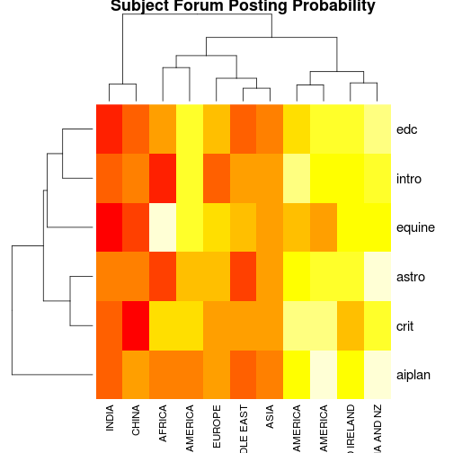

```r
heatmap(as.matrix(postProb.subj), main = "Subject Forum Posting Probability")
```

Look at each course separately because the differing levels of forum use between courses, and the quantity of data-points, confuses matters if courses are plotted side-by-side on the same bar plot.

### AI Planning

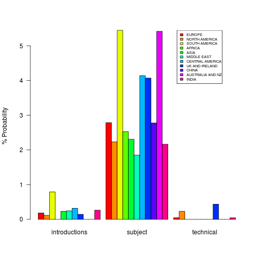

```r
plot.1course("aiplan")
```

**The numbers of people in some regions is quite small; be cautious about interpretation.**

### Astro-biology

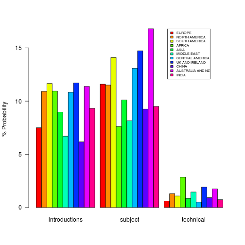

```r
plot.1course("astro")
```

### Critical Thinking

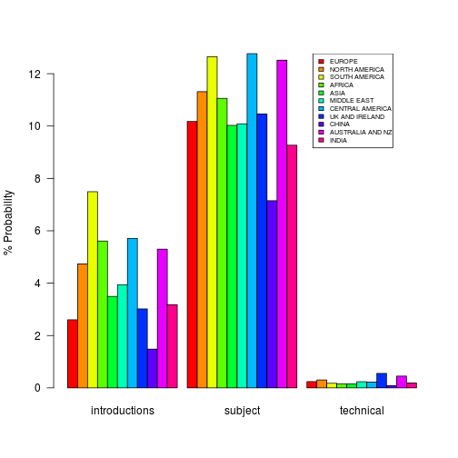

```r
plot.1course("crit")
```

### eL & DC

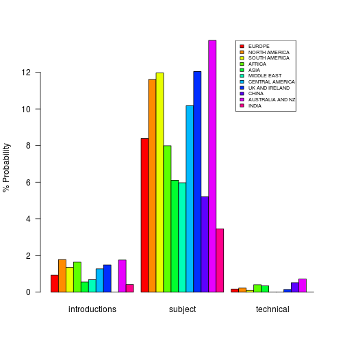

```r
plot.1course("edc")
```

### Equine Nutririon

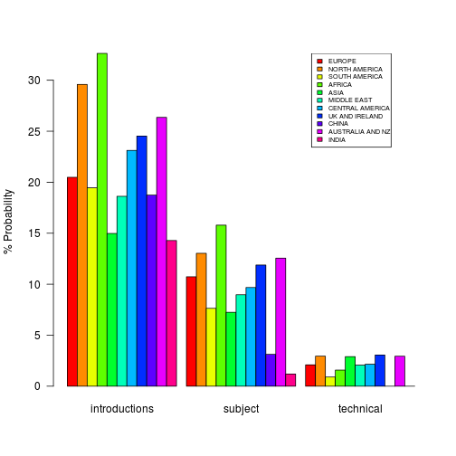

```r
plot.1course("equine")
```

### Intro to Philo

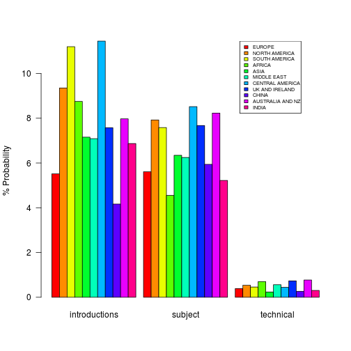

```r
plot.1course("intro")
```

### Significance

Given the sample sizes, are these differences statistically significant? Consider only the subject-matter forum posts

The following table shows the percentage chance that the number of posters can be assumed to be the same as the average for the course. A value less than 5% would be a conventional threshold for asserting that the number of people posting in that region is significantly different from what would be exected from the whole-course average. Whether it is higher or lower than the mean can be judged from previous charts.

| id | EUROPE | NORTH AMERICA | SOUTH AMERICA | AFRICA | ASIA | MIDDLE EAST | CENTRAL AMERICA | UK AND IRELAND | CHINA | AUSTRALIA AND NZ | INDIA |
| --- | --- | --- | --- | --- | --- | --- | --- | --- | --- | --- | --- |
| aiplan | 92.641 | 5.4793 | 0.0005 | 88.8650 | 35.2273 | 13.2628 | 16.399 | 4.7113 | 100.0000 | 2.6670 | 8.3557 |
| astro | 48.842 | 27.8387 | 1.1317 | 5.4949 | 7.7571 | 3.0102 | 48.534 | 0.0115 | 14.5543 | 0.0593 | 1.2935 |
| crit | 17.808 | 3.5360 | 0.2138 | 58.4174 | 24.3220 | 58.4356 | 3.889 | 85.5579 | 0.0081 | 7.1725 | 2.4902 |
| edc | 0.025 | 0.0002 | 0.1257 | 19.5477 | 0.0001 | 0.1328 | 73.718 | 0.0968 | 0.1432 | 0.0076 | 0.0000 |
| equine | 10.268 | 0.5975 | 0.0497 | 11.4766 | 4.0501 | 36.7098 | 42.686 | 95.8777 | 3.0743 | 46.0422 | 0.0551 |
| intro | 0.000 | 0.0000 | 9.5327 | 0.5594 | 17.9806 | 34.7104 | 3.941 | 3.2638 | 21.7357 | 2.5148 | 0.0096 |

## Average Number of Posts per Person

Average posts per person (AI planning excluded) in the subject-matter forums.

```
## SELECT c.ip_continent continent, c.ip_country country, count(1) users
##                      FROM vpodata_aiplanfor.forum_posts fp
## JOIN vpodata_aiplanmap.hash_mapping m ON m.forum_user_id = fp.forum_user_id
## JOIN vpodata_aiplangen.uoe_ip_country c ON m.anon_user_id = c.anon_user_id
## JOIN vpodata_aiplangen.users u ON m.anon_user_id = u.anon_user_id
## JOIN  vpodata_aiplanfor.forum_threads ft ON fp.thread_id = ft.id
## JOIN  vpodata_aiplanfor.forum_forums ff ON ft.forum_id = ff.id
## WHERE u.access_group_id = 4 AND fp.deleted=0 AND fp.is_spam = 0 AND ft.deleted=0 AND ft.is_spam=0
## AND ff.deleted=0 AND ff.id NOT IN (10,9) GROUP BY continent, country
```

| id | EUROPE | NORTH AMERICA | SOUTH AMERICA | AFRICA | ASIA | MIDDLE EAST | CENTRAL AMERICA | UK AND IRELAND | CHINA | AUSTRALIA AND NZ | INDIA |
| --- | --- | --- | --- | --- | --- | --- | --- | --- | --- | --- | --- |
| astro | 0.3237 | 0.4123 | 0.3959 | 0.1524 | 0.3721 | 0.2216 | 0.4937 | 0.6166 | 0.1883 | 0.5131 | 0.2066 |
| crit | 0.1970 | 0.2522 | 0.2446 | 0.2488 | 0.2242 | 0.2088 | 0.2856 | 0.3063 | 0.1439 | 0.3123 | 0.1971 |
| edc | 0.3448 | 0.4018 | 0.3823 | 0.2193 | 0.1645 | 0.1672 | 0.3402 | 0.3419 | 0.1797 | 0.5145 | 0.0870 |
| equine | 0.4403 | 0.5072 | 0.1856 | 0.8579 | 0.1739 | 0.2276 | 0.3065 | 0.4986 | 0.0469 | 0.8531 | 0.0238 |
| intro | 0.1369 | 0.2785 | 0.1720 | 0.1739 | 0.1699 | 0.1677 | 0.1863 | 0.3208 | 0.1578 | 0.2284 | 0.1071 |

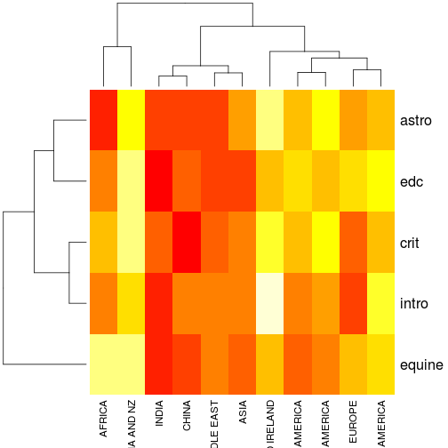

```r
heatmap(as.matrix(postsPerPerson.subj.x))
```

### Comparing Courses

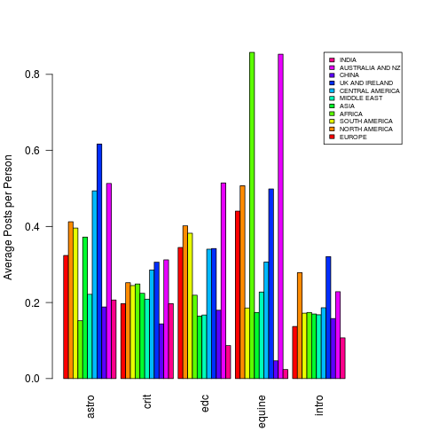

```r
cols <- rainbow(length(postsPerPerson.subj.x[1, ]))
par(mar = c(5.1, 4.1, 4.1, 7.1), xpd = TRUE)
barplot(t(as.matrix(postsPerPerson.subj.x)), ylab = "Average Posts per Person",
    col = cols, las = 2, beside = T)
legend("topright", inset = c(-0.15, 0), legend = rev(colnames(userRegions.df)),
    fill = rev(cols), cex = 0.6)
```

### Comparing Regions

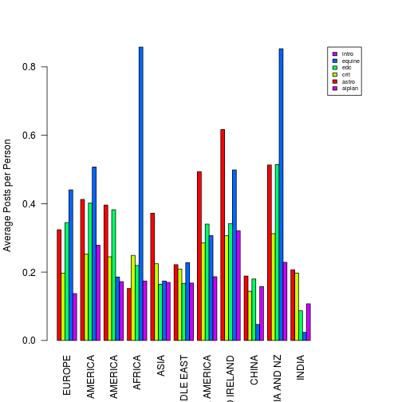

```r
cols <- rainbow(length(postsPerPerson.subj.x[, 1]))
par(mar = c(5.1, 4.1, 4.1, 7.1), xpd = TRUE)
barplot(as.matrix(postsPerPerson.subj.x), ylab = "Average Posts per Person",
    col = cols, las = 2, beside = T)
legend("topright", inset = c(-0.15, 0), legend = rev(rownames(userRegions.df)),
    fill = rev(cols), cex = 0.6)
```

### Significance

Given the sample sizes, are these differences statistically significant?

[output not shown]

## Regional Distribution of Most Active Users

**could also compare the regional split in the top decile of posters compared to the overall regional split**

## Other Ideas

Could repeat for thread-reads. I expect little variation in reads:people between regions. Differences in post:read ratio are effectively already shown above.

```
## Saved to Regional Differences.RData
```

```
## [1] TRUE
```